# EDA

Giuseppe Pagliuca

February 14, 2018

> Note: functions called below are defined in a dedicated hidden chunk above. [Here](https://github.com/gpagliuca/npl) the full code

## NPL - EDA

This document is an exploratory analysis of text data related to the Capstone Project for the Johns Hopkins Data Science Specialization. Aim of this EDA is to familiarize with the data, answer some preliminary questions and prepare the modeling work.

## Intro, data downloading and sampling

The raw data can be found: here. Our first task is to download the data (in case it was not done before):

```r
get_data()
```

Because of the data size (> 500 mb), the second step is to sample a portion of data. `rbinom` has been used for this purpose sampling 5% of the original data. This sampled data is saved in new txt files:

```r
## Sampling (if needed) and loading data
sample_size <- 0.05
if (!file.exists(paste(working_path, sample_size, ".en_US.blogs.txt", sep=''))) {
  sampling(sample_size)
}
sampled_data <- loading(sample_size)
```

## Sampled data loading and pre-processing

Now we have to load the sampled data and pre-process it. The pre-process step: * merges the text per language * remove the punctuation * remove the numbers * order the text corpus per word frequency

A `cutoff` optional parameter is available in case short words have to be excluded.

```r
# Text preprocessing
merged_text <- merge_text(sampled_data, cutoff=0)
```

```
## [1] " * Merging... English"
## [1] " * Merging... German"
## [1] " * Merging... Finnish"
## [1] " * Merging... Russian"
```

## Word counting

```r
sapply(sapply(sampled_data, strsplit, ' '), length)
```

```
## en_blog en_news   en_tw de_blog de_news   de_tw fi_blog fi_news   fi_tw
##   44917   50497  118272   18527   12326   47334   22000   24310   14307
## ru_blog ru_news   ru_tw
##   16793    9943   43991
```

## Word frequency

This is the word frequency of the most frequent 10 words assuming no cutoff on the word length is applied:

```r
## Frequencies
freq_en <- freq(merged_text$en, 'English')
freq_de <- freq(merged_text$de, 'German')
freq_fi <- freq(merged_text$fi, 'Finnish')
freq_ru <- freq(merged_text$ru, 'Russian')
fr <- (cbind(head(freq_en, 10),
             head(freq_de, 10),
             head(freq_fi, 10),
             head(freq_ru, 10)))
print(fr)
```

```
##    English   Freq German  Freq Finnish  Freq Russian  Freq
## 1      the 211149    die 45004      ja 39676       в 40562
## 2       to 135527    der 41373      on 33211       и 37621
## 3      and 113721    und 39881    että 13172      на 22590
## 4        a 113255     in 25329      ei 12573      не 22444
## 5       of  99404    ich 19466     oli  7490     что 14264
## 6       in  77035    das 19131      se  6652       с 14152
## 7        I  75667    ist 18930   mutta  6156      по  9105
## 8      for  52490    den 18166     ole  5530       я  8980
## 9       is  52083  nicht 17467     kun  5314       а  7582
## 10    that  49191     zu 17133    ovat  4975     это  6979
```

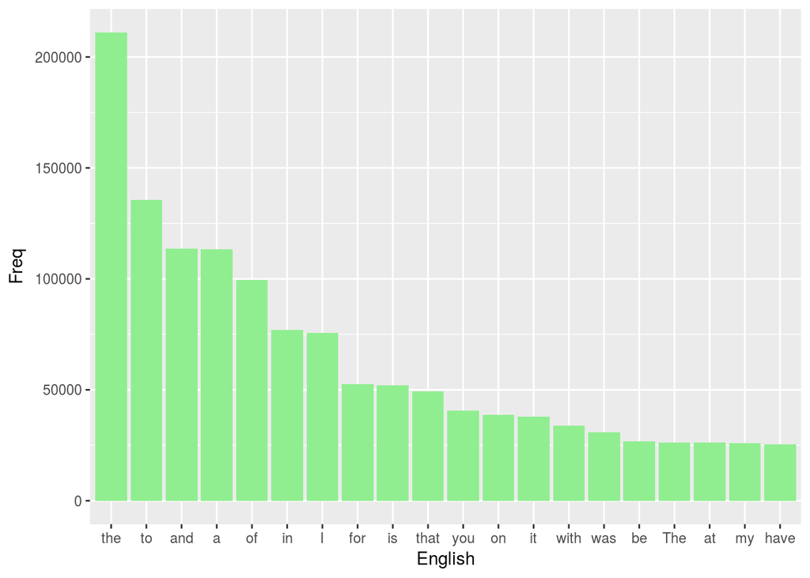

```r
f <- head(freq_en, 20)
ggplot(f) + geom_bar(aes(x = English, y = Freq), stat = "identity", fill='lightgreen')
```

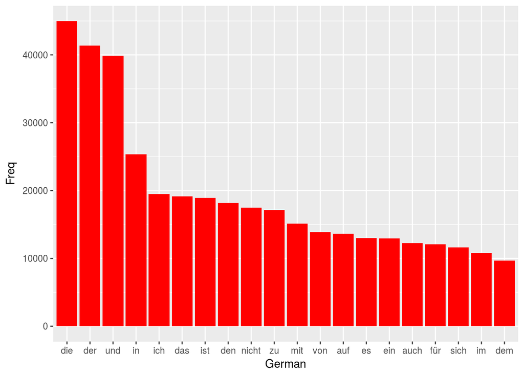

```r
f <- head(freq_de, 20)
ggplot(f) + geom_bar(aes(x = German, y = Freq), stat = "identity", fill='red')
```

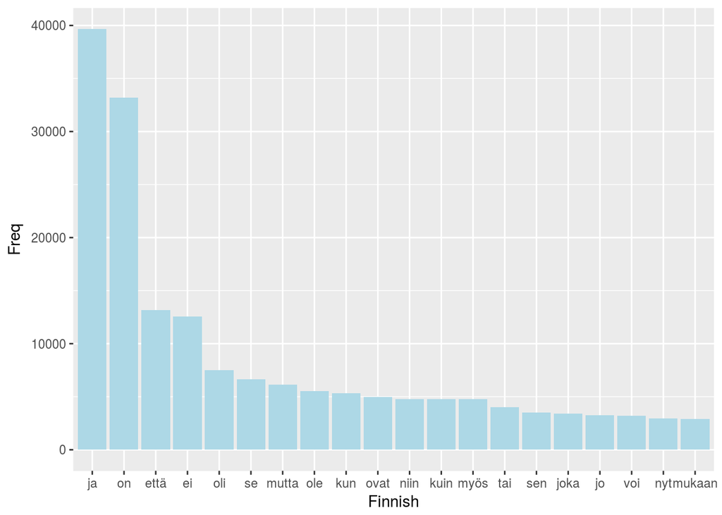

```r
f <- head(freq_fi, 20)
ggplot(f) + geom_bar(aes(x = Finnish, y = Freq), stat = "identity", fill='lightblue')
```

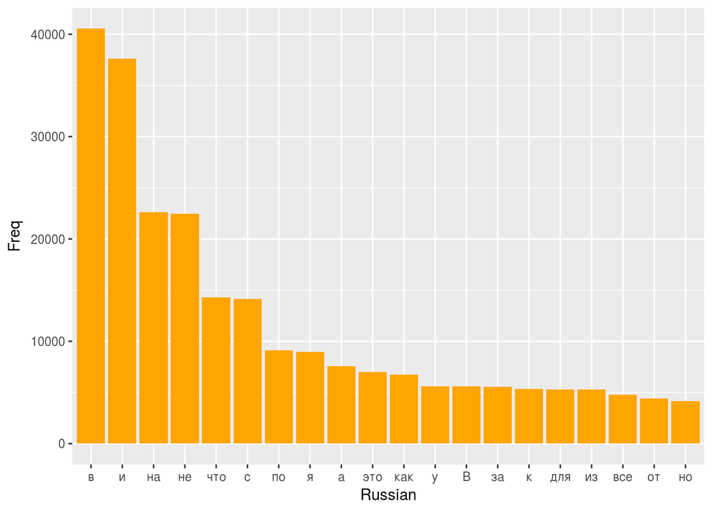

```r
f <- head(freq_ru, 20)
ggplot(f) + geom_bar(aes(x = Russian, y = Freq), stat = "identity", fill='orange')
```

## Plotting: words frequency in function of the dictionary

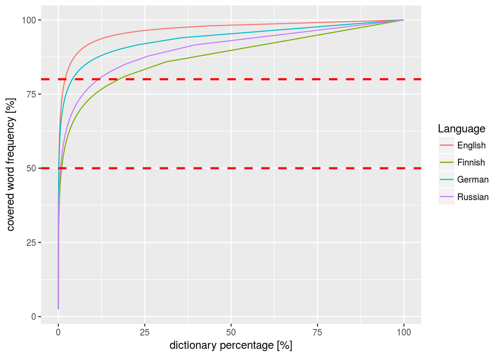

## N-grams

N-grams can be easily defined with the help of the `tokenizers` package:

```r
en_corpus <- paste(merged_text$en, collapse=' ')
en_ngrams_10 <- head(freq(tokenize_ngrams(en_corpus, n=3, n_min=3), 'English'), 10)
en_ngrams_10
```

```
##           English Freq
## 1      one of the 1795
## 2        a lot of 1569
## 3  thanks for the 1174
## 4         to be a  909
## 5     going to be  854
## 6      the end of  757
## 7      as well as  718
## 8        it was a  718
## 9       i want to  716
## 10     out of the  674
```

This are the 10 most frequent 3-grams for the whole (sampled) English text.

## Open questions

1. Is the sampling size, 5%, representative?
2. Is there any significant difference between blogs, news and twitter?